# EMScopula: teeth and AREDS applications

We fit our EMS copula model to the teeth and AREDS data in [Sun, Cheng and Ding (2023)](https://doi.org/10.1111/biom.13807).

The original paper uses Turnbull estimates for the marginal distributions and various parametric copulas for the dependence structure. They proposed a goodness-of-fit procedure to select the best copula model.

As the EMS approach requires a finite upper endpoint for right-censored observations, we set it to 30 years.

```r
library(EMScopula)
library(icenReg)
library(copula)

upper_cap_years <- 30
u <- seq(.02, .98, length.out = 97)
uv <- as.matrix(expand.grid(u, u))
colors <- hcl.colors(100, "YlOrRd", rev = TRUE)
```

## Teeth 34 and 44

The public `icensBKL::tandmobAll` data contain emergence ages in years, for teeth 34 and 44 in **4,430 children**, with left, interval and right censoring.

Dentists examined a cohort of children annually, beginning in their first year of elementary school. The dataset records tooth emergence times, which are interval-censored because emergence was assessed only at these examinations.

All methods below are fitted to these same 4,430 children. The paper use 300-child subsets for their analysis, but I haven’t found the exact subset they used.

```r
load("tandmobAll.rda")
teeth <- data.frame(
  Left.L = tandmobAll$EBEG.34, Right.L = tandmobAll$EEND.34,
  status.L = as.integer(!is.na(tandmobAll$EEND.34)),
  Left.R = tandmobAll$EBEG.44, Right.R = tandmobAll$EEND.44,
  status.R = as.integer(!is.na(tandmobAll$EEND.44))
)
teeth$Left.L[is.na(teeth$Left.L)] <- 0
teeth$Left.R[is.na(teeth$Left.R)] <- 0
teeth$Right.L[is.na(teeth$Right.L)] <- Inf
teeth$Right.R[is.na(teeth$Right.R)] <- Inf
tooth34 <- teeth[, c("Left.L", "Right.L", "status.L")]
tooth44 <- teeth[, c("Left.R", "Right.R", "status.R")]
names(tooth34) <- names(tooth44) <- c("Left", "Right", "status")

# Only the EMS input replaces infinite upper endpoints.
lower <- as.matrix(teeth[, c("Left.L", "Left.R")])
upper <- as.matrix(teeth[, c("Right.L", "Right.R")])
upper[is.infinite(upper)] <- upper_cap_years
```

```r
margins <- fit_marginals(
  lower, upper, multipliers = c(0.25, .5, 1, 2, 4, 8), n_folds = 5,
  seed = 123, maxit = 2000, tol = 1e-5, mc.cores = 4
)
ems <- fit_copula(
  lower, upper, margins = margins, bandwidth = "separate", round = .05,
  multipliers = c(.25, .5, 1, 2, 4, 8), n_folds = 5,
  seed = 123, maxit = 2000, tol = 1e-5, mc.cores = 8
)
cat("Marginal bandwidths (34, 44; years):", round(margins$h, 4), "\n")
```

```
Marginal bandwidths (34, 44; years): 3.762 0.4696
```

```r
cat("Copula bandwidths (normal-score scale):", round(ems$h, 4), "\n")
```

```
Copula bandwidths (normal-score scale): 0.1577 0.2455
```

```r
cv <- margins$cv[[1]]$summary
cv$selected <- cv$multiplier == margins$cv[[1]]$best_multiplier
knitr::kable(cv, digits = 4, row.names = FALSE)
```

| multiplier | h | total_holdout_loglik | mean_holdout_loglik | all_converged | converged_folds | selected |
| --- | --- | --- | --- | --- | --- | --- |
| 0.25 | 0.2351 | -5646.838 | -1129.368 | TRUE | 5 | FALSE |
| 0.50 | 0.4703 | -5643.515 | -1128.703 | TRUE | 5 | FALSE |
| 1.00 | 0.9405 | -5640.942 | -1128.188 | TRUE | 5 | FALSE |
| 2.00 | 1.8810 | -5639.741 | -1127.948 | TRUE | 5 | FALSE |
| 4.00 | 3.7620 | -5639.630 | -1127.926 | TRUE | 5 | TRUE |
| 8.00 | 7.5241 | -5639.650 | -1127.930 | TRUE | 5 | FALSE |

```r
cv <- margins$cv[[2]]$summary
cv$selected <- cv$multiplier == margins$cv[[2]]$best_multiplier
knitr::kable(cv, digits = 4, row.names = FALSE)
```

| multiplier | h | total_holdout_loglik | mean_holdout_loglik | all_converged | converged_folds | selected |
| --- | --- | --- | --- | --- | --- | --- |
| 0.25 | 0.2348 | -5627.338 | -1125.468 | TRUE | 5 | FALSE |
| 0.50 | 0.4696 | -5625.928 | -1125.186 | TRUE | 5 | TRUE |
| 1.00 | 0.9392 | -5626.784 | -1125.357 | TRUE | 5 | FALSE |
| 2.00 | 1.8784 | -5629.622 | -1125.924 | TRUE | 5 | FALSE |
| 4.00 | 3.7568 | -5630.650 | -1126.130 | TRUE | 5 | FALSE |
| 8.00 | 7.5137 | -5630.856 | -1126.171 | TRUE | 5 | FALSE |

```r
cv <- ems$cv$summary
cv$multiplier_1 <- ems$candidates$multiplier_1[cv$candidate]
cv$multiplier_2 <- ems$candidates$multiplier_2[cv$candidate]
cv$selected <- cv$candidate == ems$cv$best_candidate
knitr::kable(cv, digits = 4, row.names = FALSE)
```

| candidate | h1 | h2 | rho | score | all_converged | converged_folds | multiplier_1 | multiplier_2 | selected |
| --- | --- | --- | --- | --- | --- | --- | --- | --- | --- |
| 1 | 0.1577 | 0.1228 | 0 | -9197.579 | TRUE | 5 | 0.25 | 0.25 | FALSE |
| 2 | 0.3154 | 0.1228 | 0 | -9184.742 | TRUE | 5 | 0.50 | 0.25 | FALSE |
| 3 | 0.6309 | 0.1228 | 0 | -9213.576 | TRUE | 5 | 1.00 | 0.25 | FALSE |
| 4 | 1.2617 | 0.1228 | 0 | -9246.302 | TRUE | 5 | 2.00 | 0.25 | FALSE |
| 5 | 2.5234 | 0.1228 | 0 | -9291.953 | TRUE | 5 | 4.00 | 0.25 | FALSE |
| 6 | 5.0468 | 0.1228 | 0 | -9297.996 | TRUE | 5 | 8.00 | 0.25 | FALSE |
| 7 | 0.1577 | 0.2455 | 0 | -9176.028 | TRUE | 5 | 0.25 | 0.50 | TRUE |
| 8 | 0.3154 | 0.2455 | 0 | -9176.145 | TRUE | 5 | 0.50 | 0.50 | FALSE |
| 9 | 0.6309 | 0.2455 | 0 | -9199.880 | TRUE | 5 | 1.00 | 0.50 | FALSE |
| 10 | 1.2617 | 0.2455 | 0 | -9247.905 | TRUE | 5 | 2.00 | 0.50 | FALSE |
| 11 | 2.5234 | 0.2455 | 0 | -9281.292 | TRUE | 5 | 4.00 | 0.50 | FALSE |
| 12 | 5.0468 | 0.2455 | 0 | -9287.665 | TRUE | 5 | 8.00 | 0.50 | FALSE |
| 13 | 0.1577 | 0.4910 | 0 | -9191.739 | TRUE | 5 | 0.25 | 1.00 | FALSE |
| 14 | 0.3154 | 0.4910 | 0 | -9192.351 | TRUE | 5 | 0.50 | 1.00 | FALSE |
| 15 | 0.6309 | 0.4910 | 0 | -9209.945 | TRUE | 5 | 1.00 | 1.00 | FALSE |
| 16 | 1.2617 | 0.4910 | 0 | -9256.217 | TRUE | 5 | 2.00 | 1.00 | FALSE |
| 17 | 2.5234 | 0.4910 | 0 | -9278.166 | TRUE | 5 | 4.00 | 1.00 | FALSE |
| 18 | 5.0468 | 0.4910 | 0 | -9282.485 | TRUE | 5 | 8.00 | 1.00 | FALSE |
| 19 | 0.1577 | 0.9820 | 0 | -9225.167 | TRUE | 5 | 0.25 | 2.00 | FALSE |
| 20 | 0.3154 | 0.9820 | 0 | -9226.626 | TRUE | 5 | 0.50 | 2.00 | FALSE |
| 21 | 0.6309 | 0.9820 | 0 | -9250.227 | TRUE | 5 | 1.00 | 2.00 | FALSE |
| 22 | 1.2617 | 0.9820 | 0 | -9277.467 | TRUE | 5 | 2.00 | 2.00 | FALSE |
| 23 | 2.5234 | 0.9820 | 0 | -9291.651 | TRUE | 5 | 4.00 | 2.00 | FALSE |
| 24 | 5.0468 | 0.9820 | 0 | -9296.018 | TRUE | 5 | 8.00 | 2.00 | FALSE |
| 25 | 0.1577 | 1.9641 | 0 | -9254.047 | TRUE | 5 | 0.25 | 4.00 | FALSE |
| 26 | 0.3154 | 1.9641 | 0 | -9252.107 | TRUE | 5 | 0.50 | 4.00 | FALSE |
| 27 | 0.6309 | 1.9641 | 0 | -9269.266 | TRUE | 5 | 1.00 | 4.00 | FALSE |
| 28 | 1.2617 | 1.9641 | 0 | -9295.243 | TRUE | 5 | 2.00 | 4.00 | FALSE |
| 29 | 2.5234 | 1.9641 | 0 | -9303.003 | TRUE | 5 | 4.00 | 4.00 | FALSE |
| 30 | 5.0468 | 1.9641 | 0 | -9305.644 | TRUE | 5 | 8.00 | 4.00 | FALSE |
| 31 | 0.1577 | 3.9282 | 0 | -9259.959 | TRUE | 5 | 0.25 | 8.00 | FALSE |
| 32 | 0.3154 | 3.9282 | 0 | -9258.909 | TRUE | 5 | 0.50 | 8.00 | FALSE |
| 33 | 0.6309 | 3.9282 | 0 | -9272.687 | TRUE | 5 | 1.00 | 8.00 | FALSE |
| 34 | 1.2617 | 3.9282 | 0 | -9300.702 | TRUE | 5 | 2.00 | 8.00 | FALSE |
| 35 | 2.5234 | 3.9282 | 0 | -9308.058 | TRUE | 5 | 4.00 | 8.00 | FALSE |
| 36 | 5.0468 | 3.9282 | 0 | -9310.669 | TRUE | 5 | 8.00 | 8.00 | FALSE |

```r
# These CopulaCenR helpers match the authors' supplementary routines.
tb <- CopulaCenR:::Marginal_Turnbull(teeth)
families <- c("clayton", "gumbel", "frank", "gaussian", "plackett")
theta <- numeric(length(families))
for (j in seq_along(families)) {
  theta[j] <- CopulaCenR:::MLE_ic_copula_Turnbull_eta(teeth, families[j])
}

# Fix Turnbull survival probabilities through t = -log(S), so exp(-t) = S.
# Weibull parameters are fixed at 1; no Weibull margins are estimated.
copula2 <- nlminb(
  log(c(alpha = .9, kappa = .5)), CopulaCenR:::ic_copula_log_lik_param_eta,
  upper = c(0, Inf), lambda = 1, k = 1, beta = 0,
  x1 = matrix(0, nrow(teeth), 1), x2 = matrix(0, nrow(teeth), 1),
  t1_left = -log(tb$u1_left$y), t1_right = -log(tb$u1_right$y),
  t2_left = -log(tb$u2_left$y), t2_right = -log(tb$u2_right$y),
  indata1 = tooth34, indata2 = tooth44, copula = "Copula2", m.dist = "Weibull",
  control = list(rel.tol = 1e-10)
)
eta <- exp(copula2$par)
models <- list(claytonCopula(theta[1]), gumbelCopula(theta[2]),
               frankCopula(theta[3]), normalCopula(theta[4]),
               plackettCopula(theta[5]))
```

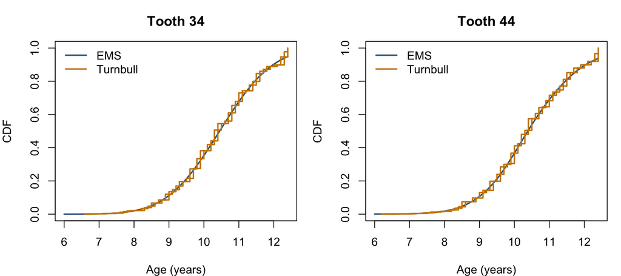

Figure 1: Marginal CDFs. Orange steps are Turnbull interval bounds.

```r
turnbull <- list(ic_np(tooth34[, c("Left", "Right")]),
                 ic_np(tooth44[, c("Left", "Right")]))
age <- seq(6, 12.4, length.out = 401)
par(mfrow = c(1, 2), mar = c(4, 4, 3, 1))
for (j in 1:2) {
  plot(age, predict(margins, age, margin = j, type = "cdf"),
       type = "l", lwd = 2, col = "steelblue4", ylim = c(0, 1),
       xlab = "Age (years)", ylab = "CDF", main = paste("Tooth", c(34, 44)[j]))
  lines(turnbull[[j]], fun = "cdf", col = "orange3", lwd = 2)
  legend("topleft", c("EMS", "Turnbull"), col = c("steelblue4", "orange3"),
         lty = 1, lwd = 2, bty = "n")
}
```

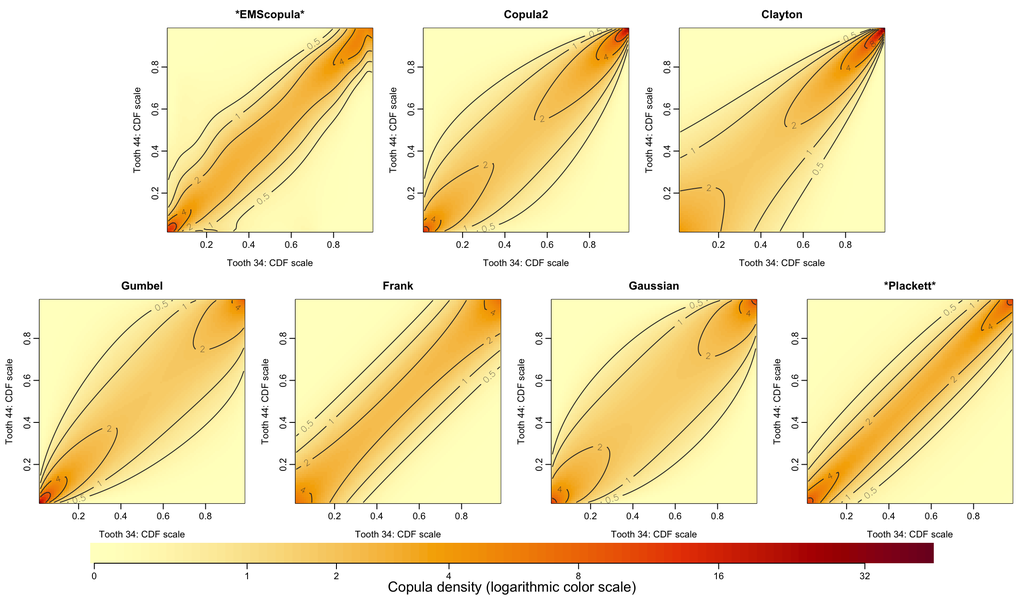

Figure 2: Copula densities on common CDF axes and a shared color scale. The paper’s survival copulas are reflected at (1-u, 1-v).

```r
# Copula2 is BB1 with theta = 1/kappa and delta = 1/alpha.
density <- list(
  predict(ems, list(u, u), type = "copula", grid = TRUE),
  matrix(VineCopula::BiCopPDF(1 - uv[, 1], 1 - uv[, 2], family = 7,
                             par = 1 / eta[2], par2 = 1 / eta[1]), length(u))
)
for (j in seq_along(models)) {
  density[[j + 2]] <- matrix(dCopula(1 - uv, models[[j]]), length(u))
}
labels <- c("*EMScopula*", "Copula2", "Clayton", "Gumbel", "Frank", "Gaussian", "*Plackett*")
z <- seq(0, log1p(max(unlist(density))), length.out = 100)
layout(rbind(c(0, 1, 1, 2, 2, 3, 3, 0), rep(4:7, each = 2), rep(8, 8)),
       heights = c(1, 1, .2))
par(mar = c(3.5, 3.5, 2.5, 1), mgp = c(2.2, .6, 0))
for (j in seq_along(density)) {
  image(u, u, log1p(density[[j]]), col = colors, zlim = range(z),
        xlab = "Tooth 34: CDF scale", ylab = "Tooth 44: CDF scale", main = labels[j])
  contour(u, u, density[[j]], levels = c(.5, 1, 2, 4, 8), add = TRUE,
          col = "grey20", labcex = .65)
}
par(mar = c(3, 8, 0, 8))
image(z, c(0, 1), cbind(z, z), col = colors, axes = FALSE, xlab = "", ylab = "")
axis(1, at = log1p(c(0, 1, 2, 4, 8, 16, 32)), labels = c(0, 1, 2, 4, 8, 16, 32))
mtext("Copula density (logarithmic color scale)", side = 1, line = 1.7)
```

## AREDS

The `CopulaCenR::AREDS` data contain **629 patients** from the Age-Related Eye Disease Study (AREDS). This study examines the time to late-stage agerelated macular degeneration (AMD) in the left and right eyes of the AMD patients. The outcomes are times to AMD in the left and right eyes, measured in years since baseline, with interval and right censoring.

- Left eyes: 335 patients were interval-censored, and 294 were right-censored.
- Right eyes: 349 patients were interval-censored, and 280 were right-censored.

```r
load("AREDS.RData")
left_eye <- AREDS[AREDS$ind == 1, c("id", "Left", "Right", "status")]
right_eye <- AREDS[AREDS$ind == 2, c("id", "Left", "Right", "status")]
areds <- merge(left_eye, right_eye, by = "id", suffixes = c(".L", ".R"))

lower <- as.matrix(areds[, c("Left.L", "Left.R")])
upper <- as.matrix(areds[, c("Right.L", "Right.R")])
upper[is.infinite(upper)] <- upper_cap_years
```

```r
margins <- fit_marginals(
  lower, upper, multipliers = c(0.25, .5, 1, 2, 4, 8), n_folds = 5,
  seed = 123, maxit = 5000, tol = 1e-5, mc.cores = 4
)
ems <- fit_copula(
  lower, upper, margins = margins, bandwidth = "separate", round = .05,
  multipliers = c(0.25, .5, 1, 2, 4, 8), n_folds = 5,
  seed = 123, maxit = 2000, tol = 1e-5, mc.cores = 8
)
cat("Marginal bandwidths (left, right; years):", round(margins$h, 4), "\n")
```

```
Marginal bandwidths (left, right; years): 0.5691 1.1267
```

```r
cat("Copula bandwidths (normal-score scale):", round(ems$h, 4), "\n")
```

```
Copula bandwidths (normal-score scale): 0.7191 0.8195
```

```r
cv <- margins$cv[[1]]$summary
cv$selected <- cv$multiplier == margins$cv[[1]]$best_multiplier
knitr::kable(cv, digits = 4, row.names = FALSE)
```

| multiplier | h | total_holdout_loglik | mean_holdout_loglik | all_converged | converged_folds | selected |
| --- | --- | --- | --- | --- | --- | --- |
| 0.25 | 0.5691 | -1170.735 | -234.1471 | TRUE | 5 | TRUE |
| 0.50 | 1.1382 | -1171.490 | -234.2980 | TRUE | 5 | FALSE |
| 1.00 | 2.2764 | -1175.296 | -235.0593 | TRUE | 5 | FALSE |
| 2.00 | 4.5528 | -1189.737 | -237.9473 | TRUE | 5 | FALSE |
| 4.00 | 9.1056 | -1211.051 | -242.2102 | TRUE | 5 | FALSE |
| 8.00 | 18.2112 | -1220.602 | -244.1204 | TRUE | 5 | FALSE |

```r
cv <- margins$cv[[2]]$summary
cv$selected <- cv$multiplier == margins$cv[[2]]$best_multiplier
knitr::kable(cv, digits = 4, row.names = FALSE)
```

| multiplier | h | total_holdout_loglik | mean_holdout_loglik | all_converged | converged_folds | selected |
| --- | --- | --- | --- | --- | --- | --- |
| 0.25 | 0.5633 | -1206.173 | -241.2345 | TRUE | 5 | FALSE |
| 0.50 | 1.1267 | -1205.894 | -241.1788 | TRUE | 5 | TRUE |
| 1.00 | 2.2533 | -1208.856 | -241.7712 | TRUE | 5 | FALSE |
| 2.00 | 4.5067 | -1220.362 | -244.0725 | TRUE | 5 | FALSE |
| 4.00 | 9.0134 | -1241.057 | -248.2115 | TRUE | 5 | FALSE |
| 8.00 | 18.0267 | -1251.174 | -250.2349 | TRUE | 5 | FALSE |

```r
cv <- ems$cv$summary
cv$multiplier_1 <- ems$candidates$multiplier_1[cv$candidate]
cv$multiplier_2 <- ems$candidates$multiplier_2[cv$candidate]
cv$selected <- cv$candidate == ems$cv$best_candidate
knitr::kable(cv, digits = 4, row.names = FALSE)
```

| candidate | h1 | h2 | rho | score | all_converged | converged_folds | multiplier_1 | multiplier_2 | selected |
| --- | --- | --- | --- | --- | --- | --- | --- | --- | --- |
| 1 | 0.0899 | 0.1024 | 0 | -2138.801 | TRUE | 5 | 0.25 | 0.25 | FALSE |
| 2 | 0.1798 | 0.1024 | 0 | -2117.694 | TRUE | 5 | 0.50 | 0.25 | FALSE |
| 3 | 0.3595 | 0.1024 | 0 | -2098.219 | TRUE | 5 | 1.00 | 0.25 | FALSE |
| 4 | 0.7191 | 0.1024 | 0 | -2089.768 | TRUE | 5 | 2.00 | 0.25 | FALSE |
| 5 | 1.4382 | 0.1024 | 0 | -2089.401 | TRUE | 5 | 4.00 | 0.25 | FALSE |
| 6 | 2.8763 | 0.1024 | 0 | -2090.010 | TRUE | 5 | 8.00 | 0.25 | FALSE |
| 7 | 0.0899 | 0.2049 | 0 | -2112.464 | TRUE | 5 | 0.25 | 0.50 | FALSE |
| 8 | 0.1798 | 0.2049 | 0 | -2101.802 | TRUE | 5 | 0.50 | 0.50 | FALSE |
| 9 | 0.3595 | 0.2049 | 0 | -2089.171 | TRUE | 5 | 1.00 | 0.50 | FALSE |
| 10 | 0.7191 | 0.2049 | 0 | -2084.339 | TRUE | 5 | 2.00 | 0.50 | FALSE |
| 11 | 1.4382 | 0.2049 | 0 | -2084.293 | TRUE | 5 | 4.00 | 0.50 | FALSE |
| 12 | 2.8763 | 0.2049 | 0 | -2084.868 | TRUE | 5 | 8.00 | 0.50 | FALSE |
| 13 | 0.0899 | 0.4098 | 0 | -2100.043 | TRUE | 5 | 0.25 | 1.00 | FALSE |
| 14 | 0.1798 | 0.4098 | 0 | -2088.791 | TRUE | 5 | 0.50 | 1.00 | FALSE |
| 15 | 0.3595 | 0.4098 | 0 | -2083.484 | TRUE | 5 | 1.00 | 1.00 | FALSE |
| 16 | 0.7191 | 0.4098 | 0 | -2080.385 | TRUE | 5 | 2.00 | 1.00 | FALSE |
| 17 | 1.4382 | 0.4098 | 0 | -2082.791 | TRUE | 5 | 4.00 | 1.00 | FALSE |
| 18 | 2.8763 | 0.4098 | 0 | -2083.736 | TRUE | 5 | 8.00 | 1.00 | FALSE |
| 19 | 0.0899 | 0.8195 | 0 | -2084.779 | TRUE | 5 | 0.25 | 2.00 | FALSE |
| 20 | 0.1798 | 0.8195 | 0 | -2082.763 | TRUE | 5 | 0.50 | 2.00 | FALSE |
| 21 | 0.3595 | 0.8195 | 0 | -2079.621 | TRUE | 5 | 1.00 | 2.00 | FALSE |
| 22 | 0.7191 | 0.8195 | 0 | -2077.743 | TRUE | 5 | 2.00 | 2.00 | TRUE |
| 23 | 1.4382 | 0.8195 | 0 | -2083.953 | TRUE | 5 | 4.00 | 2.00 | FALSE |
| 24 | 2.8763 | 0.8195 | 0 | -2079.870 | TRUE | 5 | 8.00 | 2.00 | FALSE |
| 25 | 0.0899 | 1.6390 | 0 | -2084.125 | TRUE | 5 | 0.25 | 4.00 | FALSE |
| 26 | 0.1798 | 1.6390 | 0 | -2083.286 | TRUE | 5 | 0.50 | 4.00 | FALSE |
| 27 | 0.3595 | 1.6390 | 0 | -2082.403 | TRUE | 5 | 1.00 | 4.00 | FALSE |
| 28 | 0.7191 | 1.6390 | 0 | -2078.471 | TRUE | 5 | 2.00 | 4.00 | FALSE |
| 29 | 1.4382 | 1.6390 | 0 | -2079.981 | TRUE | 5 | 4.00 | 4.00 | FALSE |
| 30 | 2.8763 | 1.6390 | 0 | -2081.497 | TRUE | 5 | 8.00 | 4.00 | FALSE |
| 31 | 0.0899 | 3.2780 | 0 | -2084.103 | TRUE | 5 | 0.25 | 8.00 | FALSE |
| 32 | 0.1798 | 3.2780 | 0 | -2083.158 | TRUE | 5 | 0.50 | 8.00 | FALSE |
| 33 | 0.3595 | 3.2780 | 0 | -2083.104 | TRUE | 5 | 1.00 | 8.00 | FALSE |
| 34 | 0.7191 | 3.2780 | 0 | -2078.855 | TRUE | 5 | 2.00 | 8.00 | FALSE |
| 35 | 1.4382 | 3.2780 | 0 | -2080.766 | TRUE | 5 | 4.00 | 8.00 | FALSE |
| 36 | 2.8763 | 3.2780 | 0 | -2082.838 | TRUE | 5 | 8.00 | 8.00 | FALSE |

```r
tb <- CopulaCenR:::Marginal_Turnbull(areds)
families <- c("clayton", "gumbel", "frank", "gaussian")
theta <- numeric(length(families))
for (j in seq_along(families)) {
  theta[j] <- CopulaCenR:::MLE_ic_copula_Turnbull_eta(areds, families[j])
}

# Copula2 again uses fixed Turnbull survival probabilities.
copula2 <- nlminb(
  log(c(alpha = .9, kappa = .5)), CopulaCenR:::ic_copula_log_lik_param_eta,
  upper = c(0, Inf), lambda = 1, k = 1, beta = 0,
  x1 = matrix(0, nrow(areds), 1), x2 = matrix(0, nrow(areds), 1),
  t1_left = -log(tb$u1_left$y), t1_right = -log(tb$u1_right$y),
  t2_left = -log(tb$u2_left$y), t2_right = -log(tb$u2_right$y),
  indata1 = left_eye, indata2 = right_eye, copula = "Copula2", m.dist = "Weibull",
  control = list(rel.tol = 1e-10)
)
eta <- exp(copula2$par)
models <- list(claytonCopula(theta[1]), gumbelCopula(theta[2]),
               frankCopula(theta[3]), normalCopula(theta[4]))
```

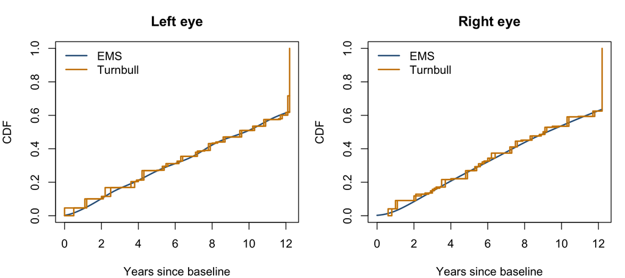

Figure 3: Marginal CDFs over the observed follow-up range. Orange steps are Turnbull interval bounds.

```r
turnbull <- list(ic_np(left_eye[, c("Left", "Right")]),
                 ic_np(right_eye[, c("Left", "Right")]))
time <- seq(0, 12.2, length.out = 401)
par(mfrow = c(1, 2), mar = c(4, 4, 3, 1))
for (j in 1:2) {
  plot(time, predict(margins, time, margin = j, type = "cdf"),
       type = "l", lwd = 2, col = "steelblue4", ylim = c(0, 1),
       xlab = "Years since baseline", ylab = "CDF", main = c("Left eye", "Right eye")[j])
  lines(turnbull[[j]], fun = "cdf", col = "orange3", lwd = 2)
  legend("topleft", c("EMS", "Turnbull"), col = c("steelblue4", "orange3"),
         lty = 1, lwd = 2, bty = "n")
}
```

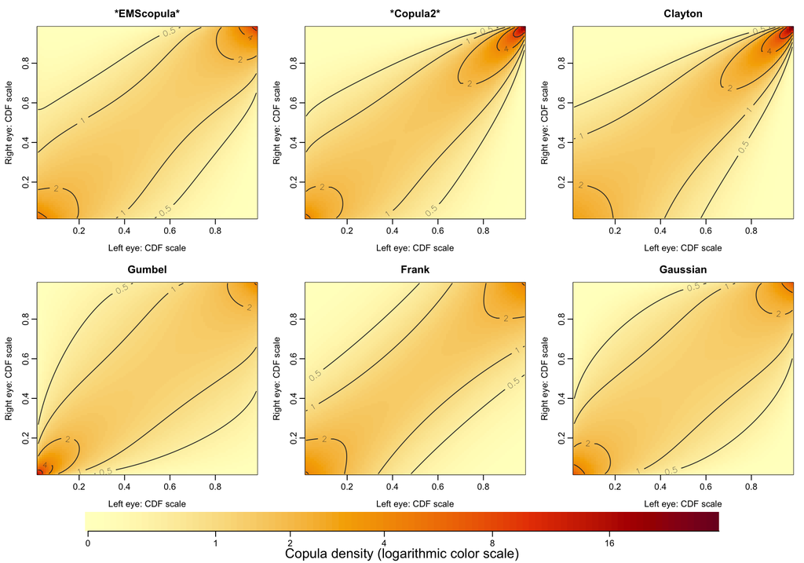

Figure 4: Copula densities for the same 629 patients, with common CDF axes and a shared color scale.

```r
density <- list(
  predict(ems, list(u, u), type = "copula", grid = TRUE),
  matrix(VineCopula::BiCopPDF(1 - uv[, 1], 1 - uv[, 2], family = 7,
                             par = 1 / eta[2], par2 = 1 / eta[1]), length(u))
)
for (j in seq_along(models)) {
  density[[j + 2]] <- matrix(dCopula(1 - uv, models[[j]]), length(u))
}
labels <- c("*EMScopula*", "*Copula2*", "Clayton", "Gumbel", "Frank", "Gaussian")
z <- seq(0, log1p(max(unlist(density))), length.out = 100)
layout(rbind(1:3, 4:6, rep(7, 3)), heights = c(1, 1, .2))
par(mar = c(3.5, 3.5, 2.5, 1), mgp = c(2.2, .6, 0))
for (j in seq_along(density)) {
  image(u, u, log1p(density[[j]]), col = colors, zlim = range(z),
        xlab = "Left eye: CDF scale", ylab = "Right eye: CDF scale", main = labels[j])
  contour(u, u, density[[j]], levels = c(.5, 1, 2, 4, 8), add = TRUE,
          col = "grey20", labcex = .65)
}
par(mar = c(3, 8, 0, 8))
image(z, c(0, 1), cbind(z, z), col = colors, axes = FALSE, xlab = "", ylab = "")
axis(1, at = log1p(c(0, 1, 2, 4, 8, 16, 32)), labels = c(0, 1, 2, 4, 8, 16, 32))
mtext("Copula density (logarithmic color scale)", side = 1, line = 1.7)
```